# Rerun-outlier-removal

Allison Davis Connelly & Sophia McKelvey

2026-04-23

# **PURPOSE:**

When exploring our data, we noticed a few outliers and wanted to investigate the how much of an effect they had on our results. With a small sample size, as we have in this experiment, it is difficult to tell if they are true outliers or within a range of natural variation. Additionally, since all identified outliers are females, it is possible that reproductive status (a factor we did not control for, although all females tested were not visibly pregnant) is altering the thermal tolerance. Therefore, these analyses are for exploratory purposes only, and we will not be removing these outliers from our final reported data set.

The analysis below is a repeat of the analyses found in *Final_temperature-analysis.Rmd* within the **Thermal Tolerance Analysis** folder. To run this current file, the *Temp ID - Completed Data.csv* from the **Thermal Tolerance Analysis** folder is required.

# **Data**

All analyses were conducted using R version 4.4.2

## Load required libraries

Remove the ‘#’ prior to `install.packages` if it is the first time installing library.

```r
#install.packages("curl")             #v5.2.1
library(curl)
#install.packages("dplyr")            #v1.1.4
library(dplyr)
#install.packages("summarytools")     #v1.1.4
library(summarytools)
#install.packages("gt")               #v0.11.1
library(gt)
#install.packages("tidyr")            #v1.3.1
library(tidyr)
#install.packages("MuMIn)              #v1.48.4
library(MuMIn)
#install.packages("lmerTest")         #v3.1.3
library(lmtest)
#install.packages("sandwich")         #v3.1-1
library(sandwich)
```

```r
#install.packages("ggplot2")          #v3.5.1
library(ggplot2)
#install.packages("ggpubr")          #v0.6.2
library(ggpubr)
#install.packages("DHARMa")           #v0.4.7
library(DHARMa)
#install.packages("emmeans")          #v1.10.5
library(emmeans)
#install.packages("car")              #v3.1-2
library(car)
#install.packages("patchwork")        #v1.3.2
library(patchwork)
```

## Read in data

```r
# OPTION 1: download 'Temp ID-Completed Data.csv' into working directory
rawTempData <- read.csv("Temp ID - Completed Data.csv", header = TRUE, sep = ",", stringsAsFactors = TRUE)
head(rawTempData)
```

```
##        Species   Mating Size.cat    Sex     Name CTmax.num CTmin.num CTmax.C
## 1 X. nigrensis courting    large   male   Charms         5         2   36.06
## 2 X. nigrensis courting    large   male Cinnamon         6         3   36.25
## 3 X. nigrensis courting    large   male   Crunch         3         5   35.94
## 4 X. nigrensis     <NA>      reg female    Lucky         4         1   35.88
## 5 X. nigrensis     <NA>      reg female    Toast         1         4   32.13
## 6 X. nigrensis     <NA>      reg female Cherrios         2         6   33.25
##   CTmin.C T.tot Size.mm
## 1    9.81 26.25    34.0
## 2    9.38 26.87    32.8
## 3    9.19 26.75    33.0
## 4   10.56 25.32    21.3
## 5    9.31 22.82    23.9
## 6    8.56 24.69    24.8
```

```r
# OPTION 2: load from Github repository
rawTempData <- curl("https://raw.githubusercontent.com/sophia-m0823/TestRStudio/main/Temp%20ID%20-%20Completed%20Data.csv")
rawTempData <- read.csv(rawTempData, header = TRUE, sep = ",", stringsAsFactors = TRUE)
head(rawTempData)
```

```
##        Species   Mating Size.cat    Sex     Name CTmax.num CTmin.num CTmax.C
## 1 X. nigrensis courting    large   male   Charms         5         2   36.06
## 2 X. nigrensis courting    large   male Cinnamon         6         3   36.25
## 3 X. nigrensis courting    large   male   Crunch         3         5   35.94
## 4 X. nigrensis     <NA>      reg female    Lucky         4         1   35.88
## 5 X. nigrensis     <NA>      reg female    Toast         1         4   32.13
## 6 X. nigrensis     <NA>      reg female Cherrios         2         6   33.25
##   CTmin.C T.tot Size.mm
## 1    9.81 26.25    34.0
## 2    9.38 26.87    32.8
## 3    9.19 26.75    33.0
## 4   10.56 25.32    21.3
## 5    9.31 22.82    23.9
## 6    8.56 24.69    24.8
```

```r
#add common names
rawTempData$Species <- factor(rawTempData$Species,
                        levels = c("X. nigrensis", "P. latipinna", "G. affinis"),
                        labels = c("Swordtail", "Sailfin", "Mosquitofish"))
```

## Identifying outliers

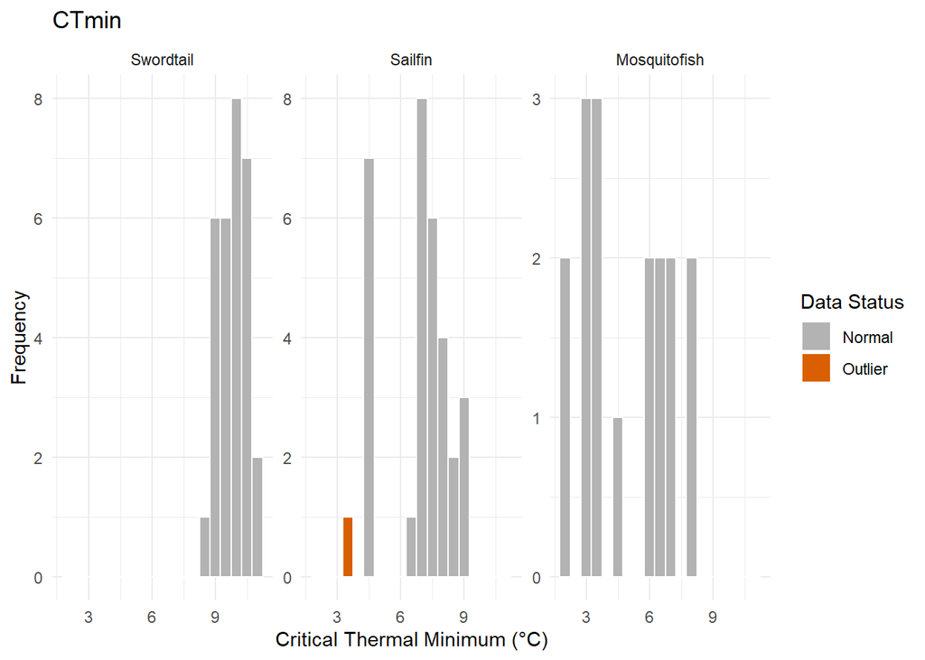

```r
#calculate outliers for both CTmax and CTmin by species
df_flagged <- rawTempData %>%
  group_by(Species) %>%
  mutate(
    q1_max = quantile(CTmax.C, 0.25, na.rm = TRUE),
    q3_max = quantile(CTmax.C, 0.75, na.rm = TRUE),
    iqr_max = q3_max - q1_max,
    q1_min = quantile(CTmin.C, 0.25, na.rm = TRUE),
    q3_min = quantile(CTmin.C, 0.75, na.rm = TRUE),
    iqr_min = q3_min - q1_min,
    is_outlier_max = CTmax.C < (q1_max - 1.5 * iqr_max) | CTmax.C > (q3_max + 1.5 * iqr_max),
    is_outlier_min = CTmin.C < (q1_min - 1.5 * iqr_min) | CTmin.C > (q3_min + 1.5 * iqr_min)) %>%
  ungroup()

#visualize CTmin outliers
out.min <- ggplot(df_flagged, aes(x = CTmin.C, fill = is_outlier_min)) +
  geom_histogram(binwidth = 0.5, color = "white") +
  facet_wrap(~Species, scales = "free_y") +
  scale_fill_manual(values = c("FALSE" = "grey70", "TRUE" = "#d95f02"),
                    name = "Data Status",
                    labels = c("Normal", "Outlier")) +
  labs(title = "CTmin",
       x = "Critical Thermal Minimum (°C)",
       y = "Frequency") +
  theme_minimal()
out.min #outliers for sailfin
```

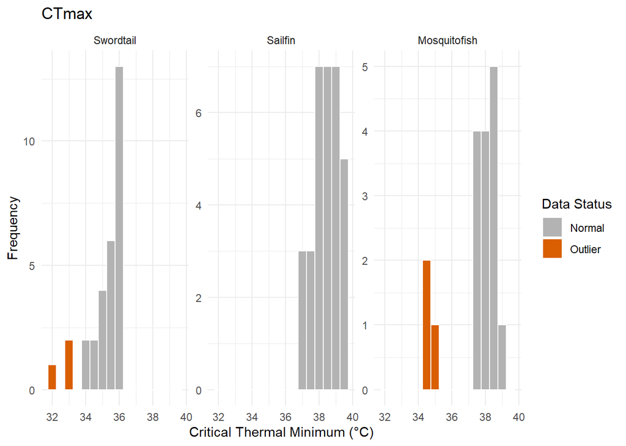

```r
#visualize CTmax outliers
out.max <- ggplot(df_flagged, aes(x = CTmax.C, fill = is_outlier_max)) +
  geom_histogram(binwidth = 0.5, color = "white") +
  facet_wrap(~Species, scales = "free_y") +
  scale_fill_manual(values = c("FALSE" = "grey70", "TRUE" = "#d95f02"),
                    name = "Data Status",
                    labels = c("Normal", "Outlier")) +
  labs(title = "CTmax",
       x = "Critical Thermal Minimum (°C)",
       y = "Frequency") +
  theme_minimal()
out.max #outliers for swordtail and mosquitofish
```

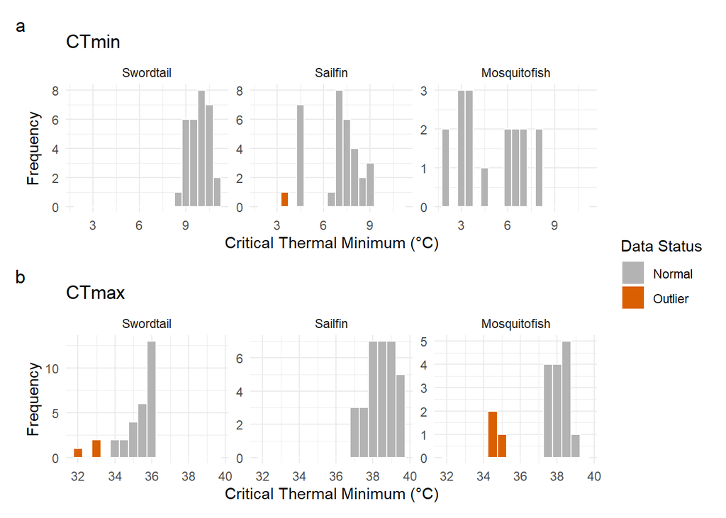

```r
((out.min/out.max) + plot_annotation(tag_levels = "a") + plot_layout(guides = "collect"))
```

```r
#filter for rows where either CTmax OR CTmin is an outlier
outlier_individuals <- df_flagged %>%
  filter(is_outlier_max | is_outlier_min) %>%
  select(Species, Sex, Name, CTmax.C, CTmin.C, is_outlier_max, is_outlier_min)
outlier_individuals #all females
```

```
## # A tibble: 7 × 7
##   Species      Sex    Name     CTmax.C CTmin.C is_outlier_max is_outlier_min
##   <fct>        <fct>  <fct>      <dbl>   <dbl> <lgl>          <lgl>
## 1 Swordtail    female Toast       32.1    9.31 TRUE           FALSE
## 2 Swordtail    female Cherrios    33.2    8.56 TRUE           FALSE
## 3 Sailfin      female Sesame      39.1    3.56 FALSE          TRUE
## 4 Swordtail    female Ellie       33.2   11.1  TRUE           FALSE
## 5 Mosquitofish female Rory        34.6    7.06 TRUE           FALSE
## 6 Mosquitofish female Loreli      35.1    6.69 TRUE           FALSE
## 7 Mosquitofish female Lane        34.6    6.5  TRUE           FALSE
```

```r
#filter out outliers from df
O.rawTempData <- rawTempData %>%
  filter(!Name %in% c("Toast", "Cherrios", "Sesame", "Ellie", "Rory", "Loreli", "Lane"))
```

## Summery stats

Trial stat changes:

- Species: CTmax OLD TEMP -> NEW TEMP; CTmin OLD TEMP -> NEW TEMP
- Swordtail: CTmax 35.27 -> 35.53; CTmin 9.86 -> 9.88
- Sailfin: CTmax 38.44 -> 38.38; CTmin 6.88 -> 6.98
- Mosquitofish: CTmax 37.58 -> 38.18; CTmin 4.95 -> 4.56

```r
#remove unnecessary columns
O.datTot <- O.rawTempData[,-c(5:7, 10)]

#create long format df to easily summarize later
O.dat.long <- O.datTot %>%
  pivot_longer(
    cols = c(CTmax.C, CTmin.C),
    names_to = "Trial",
    values_to = "Value") %>%
  mutate(
    Trial = dplyr::recode(
      Trial,
      "CTmax.C" = "CTmax",
      "CTmin.C" = "CTmin"))

#gather summary stats
O.summ.stats <- O.dat.long %>%
  group_by(Species, Trial) %>%
  summarize(
    mean = mean(Value, na.rm = TRUE),
    sd   = sd(Value, na.rm = TRUE),
    min  = min(Value, na.rm = TRUE),
    med  = median(Value, na.rm = TRUE),
    max  = max(Value, na.rm = TRUE),
    .groups = "drop")

#get n for each species and sex
O.sex.df <- O.datTot %>%
  count(Species, Sex) %>%
  tidyr::pivot_wider(
    names_from  = Sex,
    values_from = n,
    values_fill = 0)

#final table
O.summ.stats.all <- O.summ.stats %>%
  left_join(O.sex.df, by = "Species") %>%
  mutate(
    mean_sd = sprintf("%.2f (%.2f)", mean, sd))

O.summ.stats.all
```

```
## # A tibble: 6 × 10
##   Species      Trial  mean    sd   min   med   max female  male mean_sd
##   <fct>        <chr> <dbl> <dbl> <dbl> <dbl> <dbl>  <int> <int> <chr>
## 1 Swordtail    CTmax 35.5  0.626 34    35.8  36.2      12    15 35.53 (0.63)
## 2 Swordtail    CTmin  9.88 0.594  9.06  9.94 11.1      12    15 9.88 (0.59)
## 3 Sailfin      CTmax 38.4  0.772 36.8  38.4  39.8      14    16 38.38 (0.77)
## 4 Sailfin      CTmin  6.98 1.43   4.56  7.28  9.25     14    16 6.98 (1.43)
## 5 Mosquitofish CTmax 38.2  0.407 37.6  38.2  38.8       5     9 38.18 (0.41)
## 6 Mosquitofish CTmin  4.56 2.06   2.06  3.60  8         5     9 4.56 (2.06)
```

Size stat changes: since only females were removed, we will only report female changes

- Species: OLD SIZE -> NEW SIZE
- Swordtail: 23.1 -> 23.0
- Sailfin: 32.9 -> 32.8
- Mosquitofish: 30.2 -> 30.0
- Overall female size change: 28.6 -> 28.5

```r
# Average lengths by species & sex

#gather summary stats
O.sizes <- O.datTot %>%
  group_by(Species, Sex) %>%
  summarise(
    avg.len = mean(Size.mm),
    st.dev = sd(Size.mm),
    .groups = "drop")

#final table
 O.sizes.fmt <- O.sizes %>%
   mutate(
    size.display = sprintf("%.1f (%.2f)", avg.len, st.dev)) %>%
  select(Species, Sex, size.display) %>%
  pivot_wider(
    names_from = Sex,
    values_from = size.display)
O.sizes.fmt
```

```
## # A tibble: 3 × 3
##   Species      female      male
##   <fct>        <chr>       <chr>
## 1 Swordtail    23.0 (1.61) 26.5 (7.73)
## 2 Sailfin      32.8 (2.94) 33.3 (2.92)
## 3 Mosquitofish 30.0 (3.18) 21.6 (1.95)
```

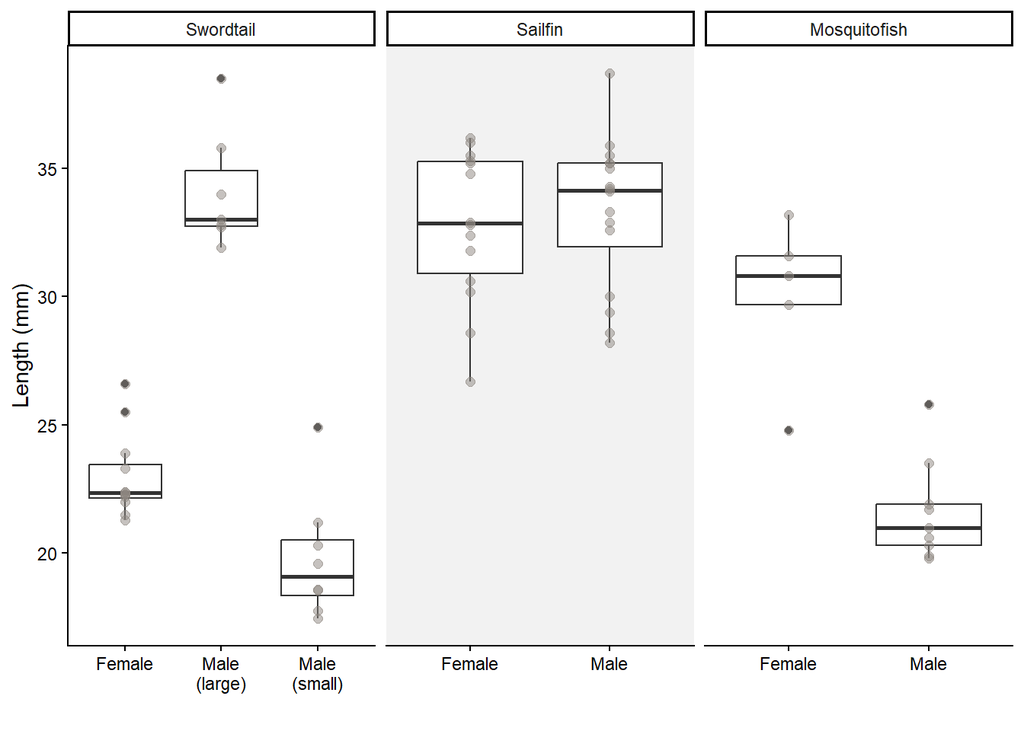

```r
### boxplot

#create more intuitive sex categories for swordtails
O.dat.plot <- O.datTot %>%
  mutate(
    O.Sex.plot = case_when(
      Species == "Swordtail" & Sex == "male" & Size.cat == "small" ~ "Male (small)",
      Species == "Swordtail" & Sex == "male" & Size.cat == "large" ~ "Male (large)",
      Sex == "male"                                             ~ "Male",
      Sex == "female"                                           ~ "Female"))


#final plot
ggplot(O.dat.plot, aes(x = O.Sex.plot, y = Size.mm)) +
  geom_rect(
    data = subset(O.datTot, Species == "Sailfin"),
    inherit.aes = FALSE,
    xmin = -Inf, xmax = Inf,
    ymin = -Inf, ymax = Inf,
    fill = "grey95") +
  geom_boxplot() +
  geom_point(color= "#8D8680", size=2, alpha=0.5) +
  facet_wrap(~ Species, scales = "free_x") +
  scale_x_discrete(
  labels = function(x) {
    ifelse(x %in% c("Male (small)", "Male (large)"),
           gsub(" ", "\n", x),
           x)}) +
  theme_classic() +
  xlab("") +
  ylab("Length (mm)")
```

```r
# Average lengths by sex

#gather summary stats
O.sizes2 <- O.datTot %>%
  group_by(Sex) %>%
  summarise(
    avg.len = mean(Size.mm),
    st.dev = sd(Size.mm),
    .groups = "drop")

#final table
 O.sizes.fmt2 <- O.sizes2 %>%
   mutate(
    size.display = sprintf("%.1f (%.2f)", avg.len, st.dev)) %>%
  select(Sex, size.display) %>%
  pivot_wider(
    names_from = Sex,
    values_from = size.display)
 O.sizes.fmt2
```

```
## # A tibble: 1 × 2
##   female      male
##   <chr>       <chr>
## 1 28.5 (5.22) 28.1 (6.89)
```

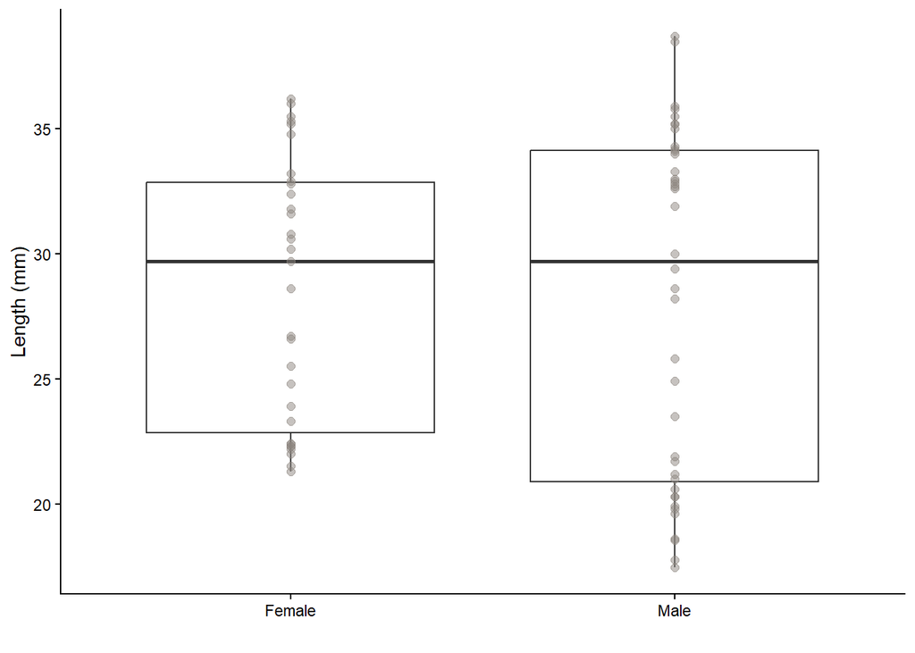

```r
### boxplot

#final plot
ggplot(O.datTot, aes(x = Sex, y = Size.mm)) +
  geom_boxplot() +
  geom_point(color= "#8D8680", size=2, alpha=0.5) +
  theme_classic() +
  xlab("") +
  ylab("Length (mm)") +
  scale_x_discrete(labels=c('Female', 'Male'))
```

# **Analysis**

## **CTmax**

### Model Selection

**Results:** The model containing just species as a dependent variable (O.mod1f) is still the most supported in our model selection (ΔAICc=0.0; weight=0.539). The model with both species and sex still has a delta value less than 2 (ΔAICc=1.25; weight=0.288), so we will still keep this model for the purpose of illustrating the limited effect of sex.

```r
# All models
O.mod1 <- lm(CTmax.C ~ Species*Sex + Size.mm, data = O.datTot) #full model with interaction effect
O.mod1b <- lm(CTmax.C ~ Species + Sex + Size.mm, data = O.datTot) #full model, no interaction
O.mod1c <- lm(CTmax.C ~ Species + Sex, data = O.datTot) #no size effect
O.mod1d <- lm(CTmax.C ~ Sex + Size.mm, data = O.datTot) #no species effect
O.mod1e <- lm(CTmax.C ~ Sex, data = O.datTot) #sex only effect
O.mod1f <- lm(CTmax.C ~ Species, data = O.datTot) #species only effect
O.mod1g <- lm(CTmax.C ~ Size.mm, data = O.datTot) #size only effect

# Model selection
model.sel(O.mod1, O.mod1b, O.mod1c, O.mod1d, O.mod1e, O.mod1f, O.mod1g)
```

```
## Model selection table
##         (Int) Sex   Siz.mm Spc Sex:Spc df   logLik  AICc  delta weight
## O.mod1f 35.53                +          4  -69.695 148.0   0.00  0.539
## O.mod1c 35.62   +            +          5  -69.162 149.2   1.25  0.288
## O.mod1b 35.39   + 0.009196   +          6  -69.009 151.3   3.33  0.102
## O.mod1  35.61   + 0.006064   +       +  8  -66.866 152.1   4.06  0.071
## O.mod1g 34.25     0.106400              3 -122.024 250.4 102.41  0.000
## O.mod1d 34.30   + 0.106100              4 -121.984 252.6 104.58  0.000
## O.mod1e 37.33   +                       3 -129.410 265.2 117.18  0.000
## Models ranked by AICc(x)
```

```r
  ### O.mod1f (species only effect) is the most supported model (ΔAICc=0; weight=0.539)
  ### O.mod1c (species and sex, no size) also has a ΔAICc < 2 (ΔAICc=1.3; weight=0.288), so will keep to illustrate the limited effects of sex, but O.mod1f is best.
```

### Residual checks

**Results:** Both the species only model (O.mod1f, most supported) and the sex and species model (O.mod1c) NO LONGER show a significant deviations from normality. Robust standard errors are no longer needed.

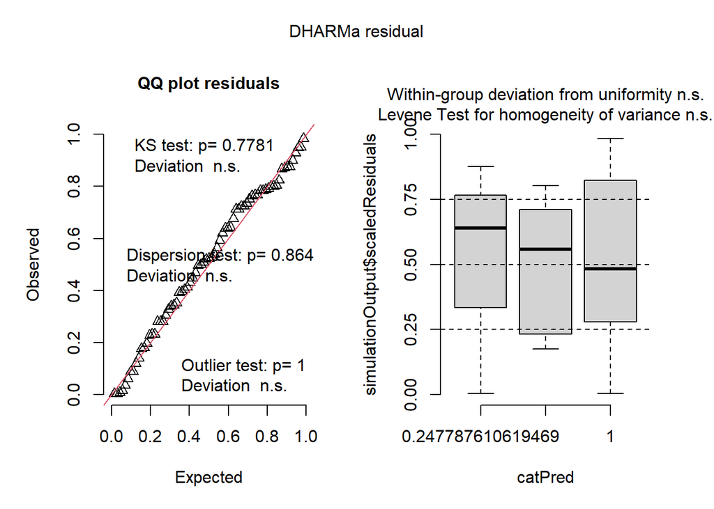

```r
# Species only model
simulationOutput <- simulateResiduals(O.mod1f)

plot(simulationOutput)
```

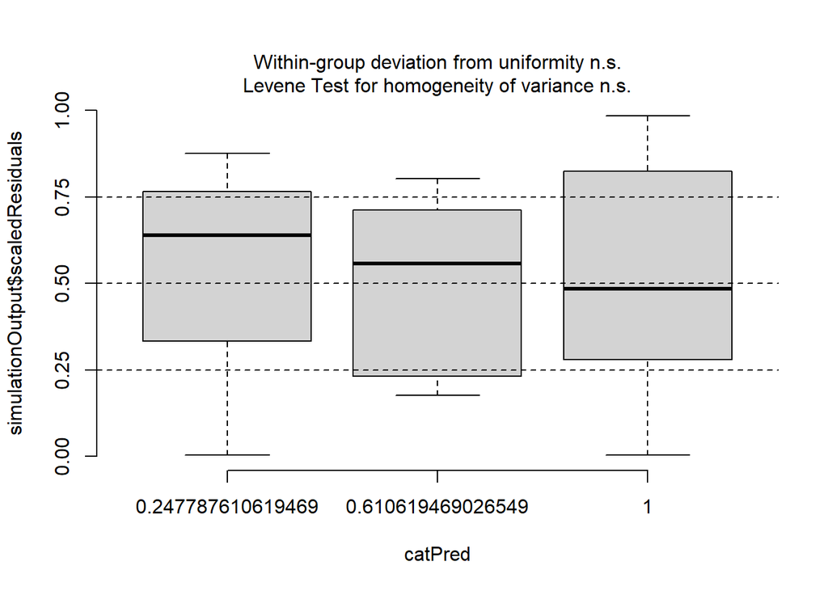

```r
plotResiduals(simulationOutput)
```

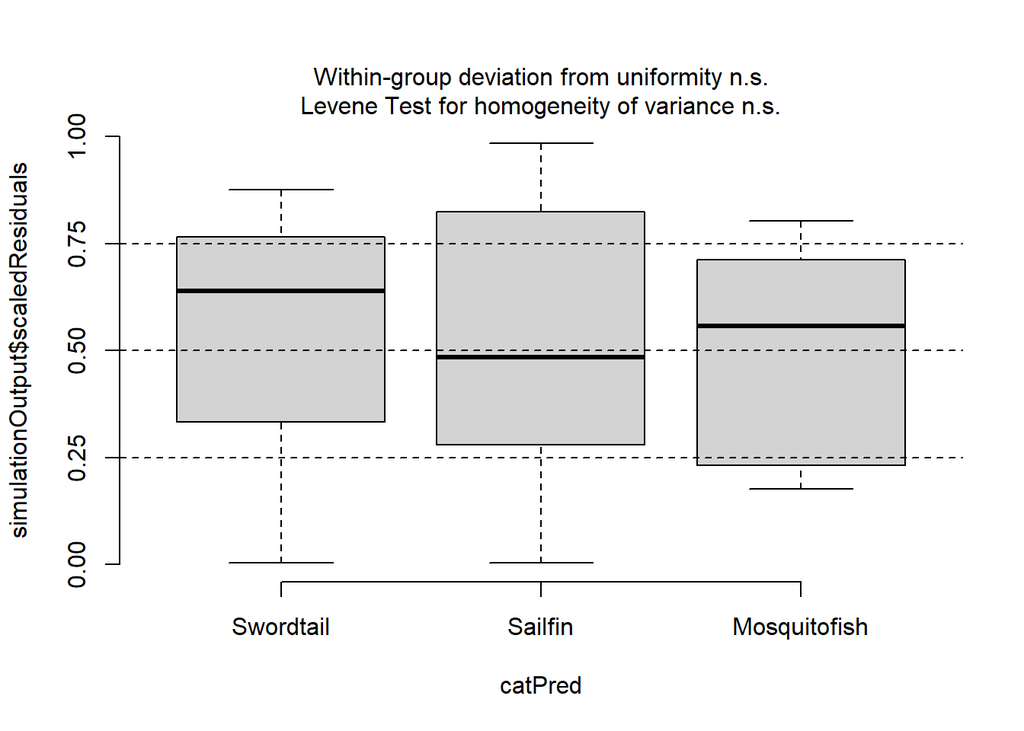

```r
plotResiduals(simulationOutput, form = O.rawTempData$Species)
```

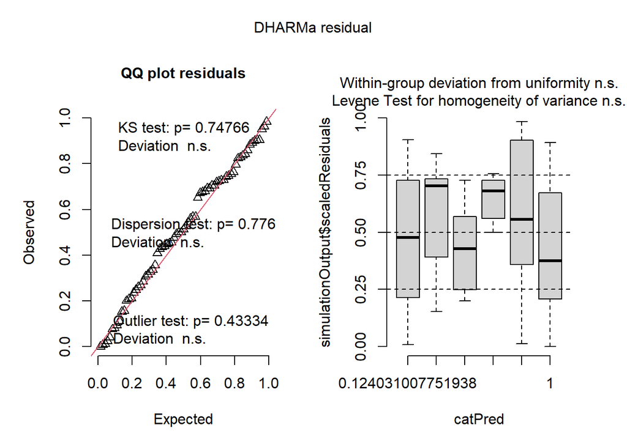

```r
   ### All good!

# Species and sex model
simulationOutput2 <- simulateResiduals(O.mod1c)

plot(simulationOutput2)
```

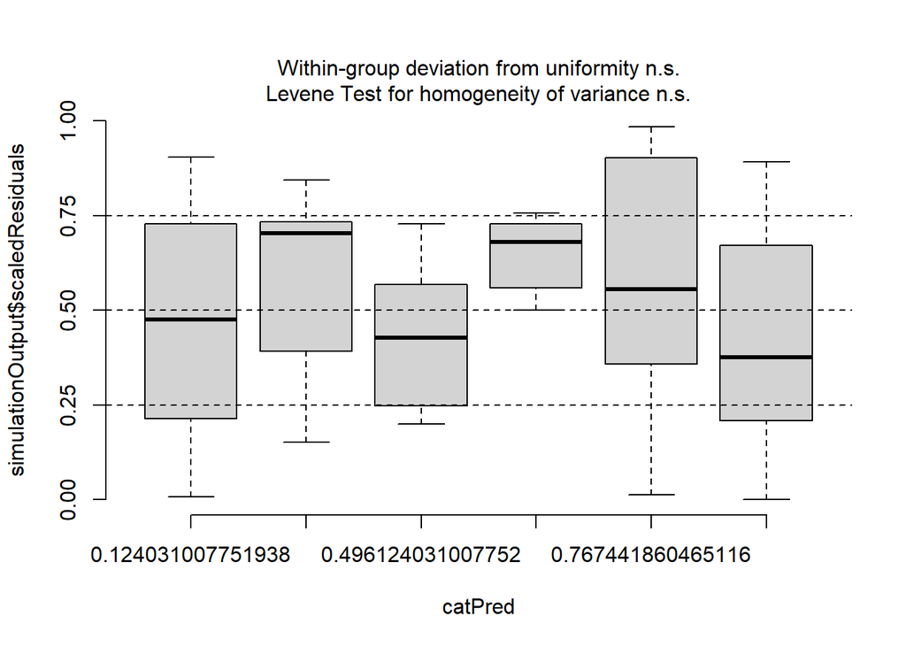

```r
plotResiduals(simulationOutput2)
```

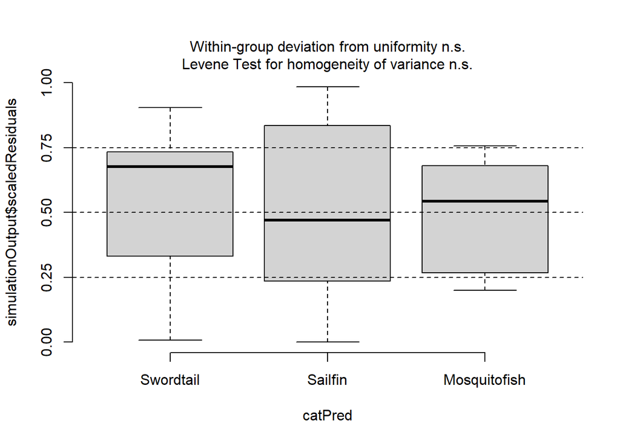

```r
plotResiduals(simulationOutput2, form = O.rawTempData$Species)
```

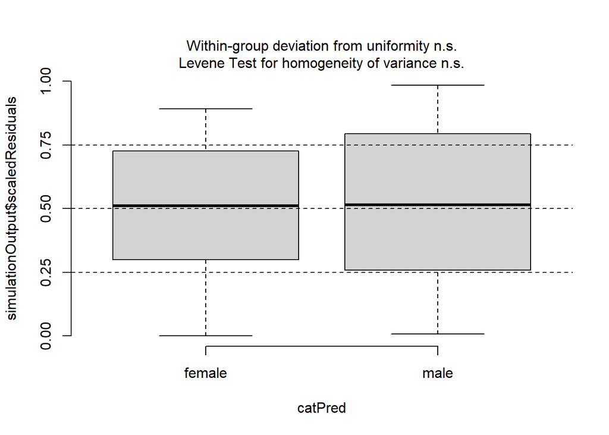

```r
plotResiduals(simulationOutput2, form = O.rawTempData$Sex)
```

```r
  ### All good!
```

### Model Summary

**Results:** There is a significant effect of species for CTmax (P<0.001). Pairwise comparisons show a significant difference between swordtails and sailfin (p<0.001) and mosquitofish (p<0.001), but no difference between sailfin & mosquitofish (p=0.620). Sex was again confirmed as a non-significant predictor in the model (estimate= -0.159, SE=0.158, p=0.318). *These results mirror full-data results.*

```r
# SPECIES ONLY MODEL

  ## Regular check (not robust)
summary(O.mod1f)
```

```
##
## Call:
## lm(formula = CTmax.C ~ Species, data = O.datTot)
##
## Residuals:
##     Min      1Q  Median      3Q     Max
## -1.5685 -0.3618  0.0615  0.4595  1.3715
##
## Coefficients:
##                     Estimate Std. Error t value Pr(>|t|)
## (Intercept)          35.5325     0.1270  279.81   <2e-16 ***
## SpeciesSailfin        2.8460     0.1750   16.26   <2e-16 ***
## SpeciesMosquitofish   2.6461     0.2173   12.18   <2e-16 ***
## ---
## Signif. codes:  0 '***' 0.001 '**' 0.01 '*' 0.05 '.' 0.1 ' ' 1
##
## Residual standard error: 0.6599 on 68 degrees of freedom
## Multiple R-squared:  0.8144, Adjusted R-squared:  0.8089
## F-statistic: 149.2 on 2 and 68 DF,  p-value: < 2.2e-16
```

```r
  ## Overall species effect
Anova(O.mod1f, type="II")
```

```
## Anova Table (Type II tests)
##
## Response: CTmax.C
##            Sum Sq Df F value    Pr(>F)
## Species   129.918  2  149.19 < 2.2e-16 ***
## Residuals  29.608 68
## ---
## Signif. codes:  0 '***' 0.001 '**' 0.01 '*' 0.05 '.' 0.1 ' ' 1
```

```r
 ## EMM & Pairwise comparisons

PW.sp.max <- emmeans(O.mod1f, "Species")
summary(PW.sp.max) #EMM
```

```
##  Species      emmean    SE df lower.CL upper.CL
##  Swordtail      35.5 0.127 68     35.3     35.8
##  Sailfin        38.4 0.120 68     38.1     38.6
##  Mosquitofish   38.2 0.176 68     37.8     38.5
##
## Confidence level used: 0.95
```

```r
pairs(PW.sp.max) #Pairwise results
```

```
##  contrast                 estimate    SE df t.ratio p.value
##  Swordtail - Sailfin         -2.85 0.175 68 -16.259 <0.0001
##  Swordtail - Mosquitofish    -2.65 0.217 68 -12.176 <0.0001
##  Sailfin - Mosquitofish       0.20 0.214 68   0.936  0.6195
##
## P value adjustment: tukey method for comparing a family of 3 estimates
```

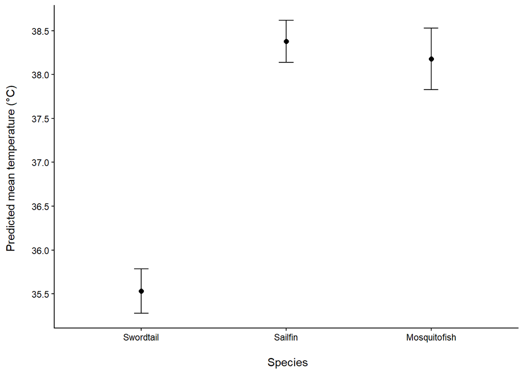

```r
  ## Plotting EMM

PW.df <- as.data.frame(PW.sp.max)

ggplot(PW.df, aes(x=Species, y=emmean)) +
  geom_point(size=2) +
  geom_errorbar(aes(ymin=lower.CL, ymax=upper.CL), width=0.1) +
  scale_y_continuous(breaks = scales::pretty_breaks(n = 10)) +
  ylab("Predicted mean temperature (°C) \n") +
  xlab("\n Species") +
  theme_classic()
```

```r
# SPECIES & SEX MODEL

summary(O.mod1c)
```

```
##
## Call:
## lm(formula = CTmax.C ~ Species + Sex, data = O.datTot)
##
## Residuals:
##      Min       1Q   Median       3Q      Max
## -1.58853 -0.37135  0.00837  0.43990  1.44590
##
## Coefficients:
##                     Estimate Std. Error t value Pr(>|t|)
## (Intercept)          35.6211     0.1545 230.566   <2e-16 ***
## SpeciesSailfin        2.8425     0.1751  16.237   <2e-16 ***
## SpeciesMosquitofish   2.6600     0.2177  12.217   <2e-16 ***
## Sexmale              -0.1594     0.1584  -1.006    0.318
## ---
## Signif. codes:  0 '***' 0.001 '**' 0.01 '*' 0.05 '.' 0.1 ' ' 1
##
## Residual standard error: 0.6598 on 67 degrees of freedom
## Multiple R-squared:  0.8172, Adjusted R-squared:  0.809
## F-statistic: 99.82 on 3 and 67 DF,  p-value: < 2.2e-16
```

## **CTmin**

### Model Selection

**Results:** The species only model (O.mod2f) was again the most supported in our model selection (ΔAICc=0.0; weight=0.416). However, the full model with no interactions (O.mod2b) and the sex and species model (O.mod2c) also have a ΔAICc <2 (full model: ΔAICc= 0.8, weight= 0.279; spp+sex: ΔAICc = 1.07, weight=0.243). We will keep these two models to illustrate the effect of size and sex on our data, but maintain the species only model (O.mod2f) as our most supported model.

```r
# All models
O.mod2 <- lm(CTmin.C ~ Species*Sex + Size.mm, data = O.datTot) #full model with interaction effect
O.mod2b <- lm(CTmin.C ~ Species + Sex + Size.mm, data = O.datTot) #full model, no interaction
O.mod2c <- lm(CTmin.C ~ Species + Sex, data = O.datTot) #no size effect
O.mod2d <- lm(CTmin.C ~ Sex + Size.mm, data = O.datTot) #no species effect
O.mod2e <- lm(CTmin.C ~ Sex, data = O.datTot) #sex only effect
O.mod2f <- lm(CTmin.C ~ Species, data = O.datTot) #species only effect
O.mod2g <- lm(CTmin.C ~ Size.mm, data = O.datTot) #size only effect

# Model selection
model.sel(O.mod2, O.mod2b, O.mod2c, O.mod2d, O.mod2e, O.mod2f, O.mod2g)
```

```
## Model selection table
##          (Int) Sex   Siz.mm Spc Sex:Spc df   logLik  AICc delta weight
## O.mod2f  9.881                +          4 -120.544 249.7  0.00  0.416
## O.mod2b 11.050   + -0.05493   +          6 -118.589 250.5  0.80  0.279
## O.mod2c  9.685   +            +          5 -119.922 250.8  1.07  0.243
## O.mod2  10.630   + -0.03803   +       +  8 -117.595 253.5  3.82  0.062
## O.mod2g  9.957     -0.08303              3 -160.912 328.2 78.49  0.000
## O.mod2d  9.877   + -0.08268              4 -160.887 330.4 80.69  0.000
## O.mod2e  7.517   +                       3 -162.524 331.4 81.71  0.000
## Models ranked by AICc(x)
```

```r
  ### O.mod2f (species only) is the most supported model (ΔAICc=0; weight=0.416)
  ### O.mod2b (full model, no interactions) also has a ΔAICc < 2 (ΔAICc=0.80; weight=0.279)
  ### O.mod2c (species + sex) also has a ΔAICc < 2 (ΔAICc=1.07; weight=0.243)
  ### Will check out the summaries below to see the degree sex and size impact the model; maintain O.mod2f as most supported
```

### Residual checks

**Results:** Both the species only model (O.mod2f) and the sex and species model (O.mod2c) are heteroscedastic. This is driven by species-level differences in variation. We will use robust standard errors to assess the significance of the effects despite this heteroscedasticity. The full model with no interaction (O.mod2b) passes residual checks, so no robust standard errors are needed.

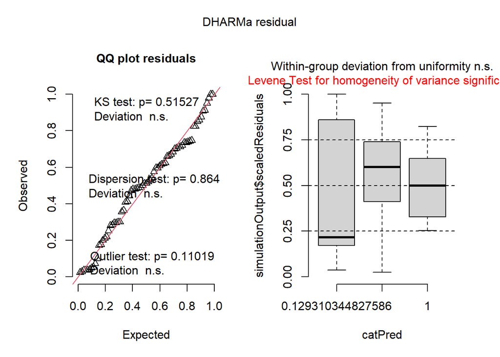

```r
# Species only model
simulationOutput <- simulateResiduals(O.mod2f)

plot(simulationOutput)
```

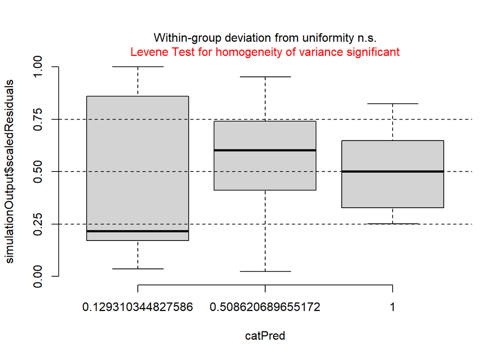

```r
plotResiduals(simulationOutput)
```

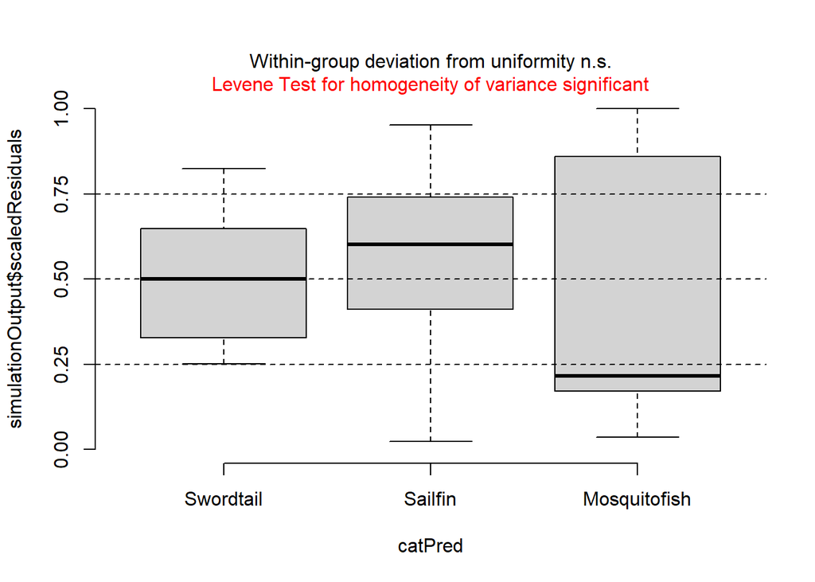

```r
plotResiduals(simulationOutput, form = O.rawTempData$Species)
```

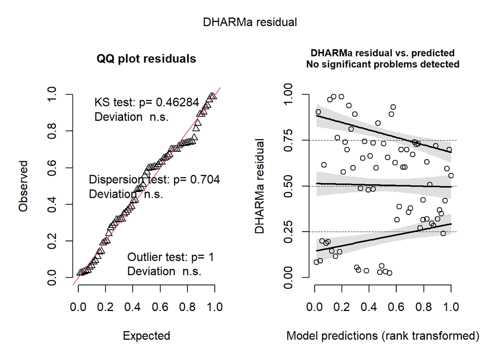

```r
  ### Failed Levene's test driven by species-level variation differences



# full model, no interactions
simulationOutput <- simulateResiduals(O.mod2b)

plot(simulationOutput)
```

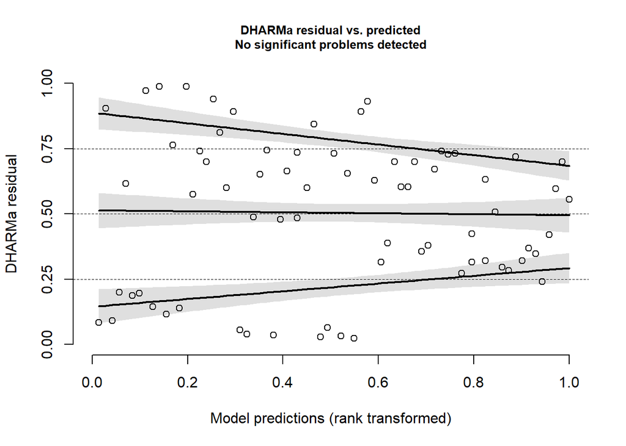

```r
plotResiduals(simulationOutput)
```

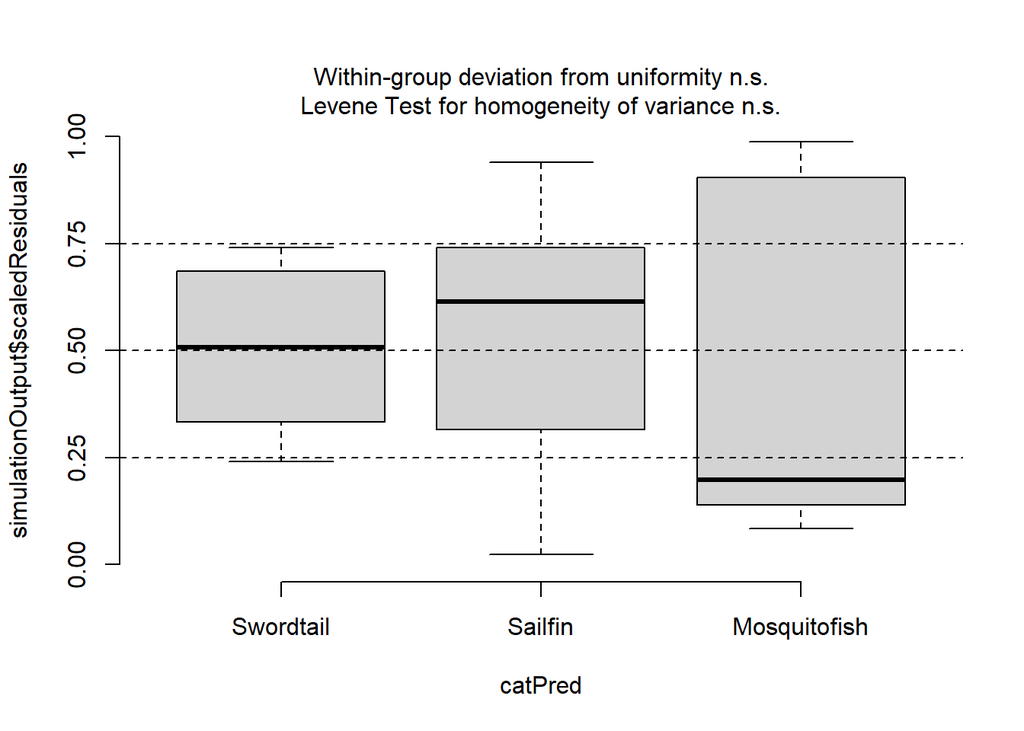

```r
plotResiduals(simulationOutput, form = O.rawTempData$Species)
```

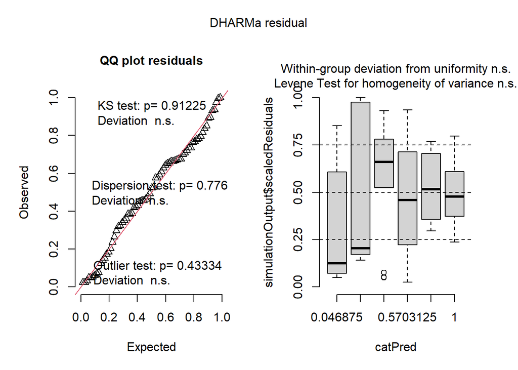

```r
  ### All good!



# Species and sex model
simulationOutput <- simulateResiduals(O.mod2c)

plot(simulationOutput)
```

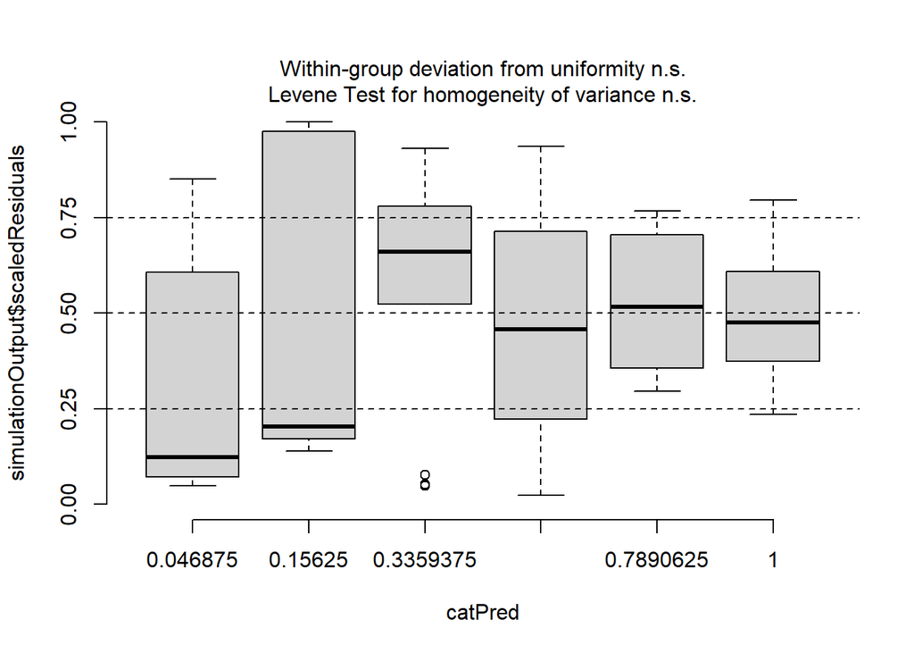

```r
plotResiduals(simulationOutput)
```

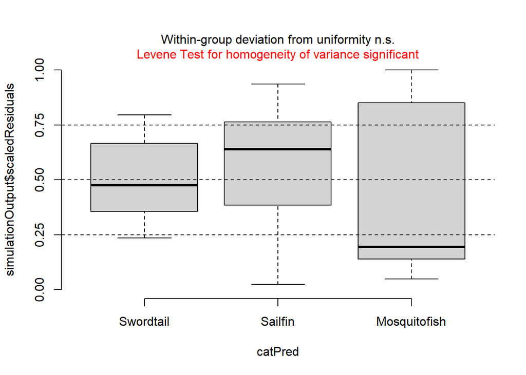

```r
plotResiduals(simulationOutput, form = O.rawTempData$Species)
```

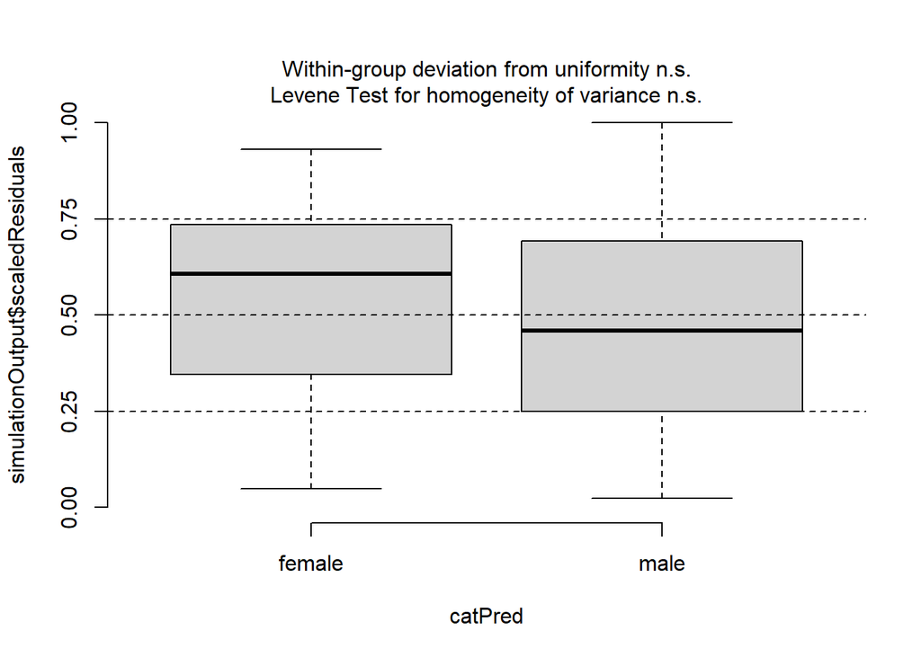

```r
plotResiduals(simulationOutput, form = O.rawTempData$Sex)
```

```r
  ### Fine in overall plots, but by species shows a failure in Levene's test
```

### Model Summary

**Results:** There is still a significant effect of species for CTmin (P<0.001). Pairwise comparisons show all species as significantly different: swordtail-sailfin= p<0.001; swordtail-mosquitofish=p<0.001; sailfin-mosquitofish= p=0.001). Sex remained a non-significant predictor in both the full model with no interactions (p=0.28) and the sex + species model (p=0.28). Additionally, size is not a significant predictor in the full model with no interactions (p=0.07). *These results mirror full-data results.*

```r
# SPECIES ONLY MODEL

## Robust variance-covariance matrix
robVCV.sp <- vcovHC(O.mod2f, type= "HC3")

 ## Overall species effect
Anova(O.mod2f, vcov = robVCV.sp, type="II")
```

```
## Coefficient covariances computed by robVCV.sp
```

```
## Analysis of Deviance Table (Type II tests)
##
## Response: CTmin.C
##           Df      F    Pr(>F)
## Species    2 84.551 < 2.2e-16 ***
## Residuals 68
## ---
## Signif. codes:  0 '***' 0.001 '**' 0.01 '*' 0.05 '.' 0.1 ' ' 1
```

```r
 ## EMM & Pairwise comparisons

PW.sp.min <- emmeans(O.mod2f, "Species", vcov. = robVCV.sp)
summary(PW.sp.min) #EMM
```

```
##  Species      emmean    SE df lower.CL upper.CL
##  Swordtail      9.88 0.117 68     9.65    10.11
##  Sailfin        6.98 0.266 68     6.45     7.51
##  Mosquitofish   4.56 0.572 68     3.42     5.70
##
## Confidence level used: 0.95
```

```r
pairs(PW.sp.min) #Pairwise results
```

```
##  contrast                 estimate    SE df t.ratio p.value
##  Swordtail - Sailfin          2.90 0.291 68   9.974 <0.0001
##  Swordtail - Mosquitofish     5.32 0.583 68   9.116 <0.0001
##  Sailfin - Mosquitofish       2.42 0.631 68   3.837  0.0008
##
## P value adjustment: tukey method for comparing a family of 3 estimates
```

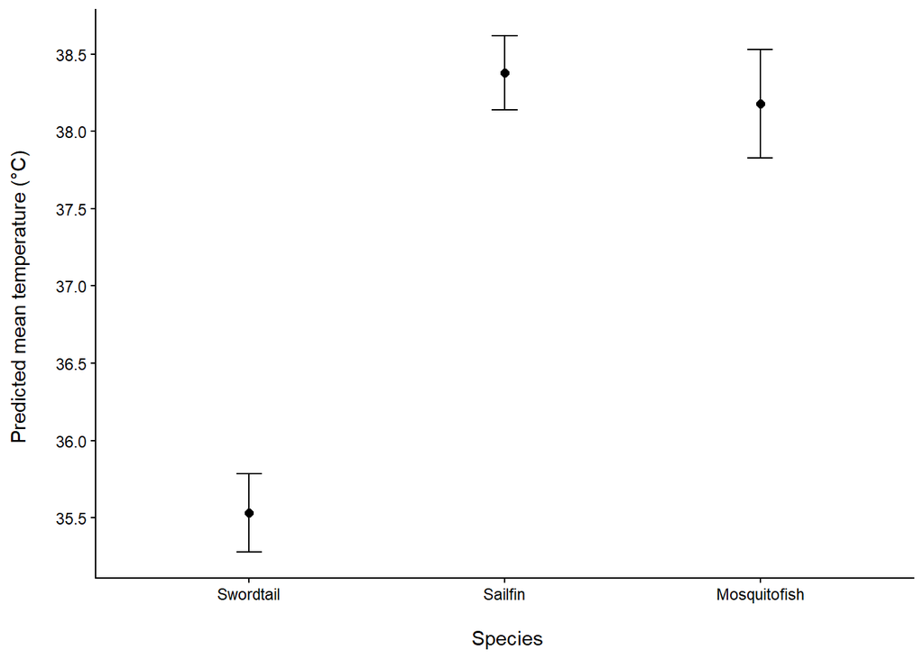

```r
 ## Plotting EMM

PW.df <- as.data.frame(PW.sp.max)

ggplot(PW.df, aes(x=Species, y=emmean)) +
  geom_point(size=2) +
  geom_errorbar(aes(ymin=lower.CL, ymax=upper.CL), width=0.1) +
  scale_y_continuous(breaks = scales::pretty_breaks(n = 10)) +
  ylab("Predicted mean temperature (°C) \n") +
  xlab("\n Species") +
  theme_classic()
```

```r
# FULL MODEL NO INTERACTIONS
coeftest(O.mod2b, vcov. = vcovHC(O.mod2b, type= "HC3")) #sex not sig (p=0.277), size not sig (p=0.070)
```

```
##
## t test of coefficients:
##
##                      Estimate Std. Error t value  Pr(>|t|)
## (Intercept)         11.053465   0.699662 15.7983 < 2.2e-16 ***
## SpeciesSailfin      -2.442982   0.388283 -6.2918 2.880e-08 ***
## SpeciesMosquitofish -5.365493   0.554913 -9.6691 2.863e-14 ***
## Sexmale              0.352971   0.322287  1.0952   0.27741
## Size.mm             -0.054928   0.029869 -1.8390   0.07042 .
## ---
## Signif. codes:  0 '***' 0.001 '**' 0.01 '*' 0.05 '.' 0.1 ' ' 1
```

```r
# SPECIES & SEX MODEL
coeftest(O.mod2c, vcov. = vcovHC(O.mod2c, type= "HC3")) #sex not sig (p=0.283)
```

```
##
## t test of coefficients:
##
##                     Estimate Std. Error t value  Pr(>|t|)
## (Intercept)          9.68527    0.21865 44.2956 < 2.2e-16 ***
## SpeciesSailfin      -2.89085    0.29757 -9.7148 2.043e-14 ***
## SpeciesMosquitofish -5.34881    0.57198 -9.3514 9.022e-14 ***
## Sexmale              0.35217    0.32539  1.0823     0.283
## ---
## Signif. codes:  0 '***' 0.001 '**' 0.01 '*' 0.05 '.' 0.1 ' ' 1
```

## **Across mating strategies**

The second aim in our analysis is to compare thermal tolerance across male mating strategies within one species (Panuco swordtail). We used swordtail males of two categories: large, courting males (standard length >32mm) or small, coercive males (standard length <25mm with clearly defined gonopodium). If preexisting sex-based differences (e.g. bright coloration, elongated fins, courtship) affect thermal tolerance, we predict large males to have a lower thermal tolerance than small males, and small males to mirror the thermal tolerance of females.

No males were removed in our outlier removal, but three female swordtails were removed.

### Models

Since male mating strategy is associated with size, adding size to our models would be redundant. Just to confirm, we will run a correlation test (kruskal-wallis of sex~size) and calculate colinearity (variance inflation factor, GVIF). To do this, we created a new sex column with three factors: female, male.large, and male.small. That way we won’t have to worry about one of our groups (ie females) not having a factor for mating strategy.

```r
# Create swordtail only data set
O.swordtail_1 <- O.datTot[O.datTot$Species =="Swordtail",]

# Create a new sex column based off size categories
O.swordtail_1 <- O.swordtail_1 %>%
  mutate(sex.2 = dplyr::recode(Size.cat,
                        "large" = "male.courtship",
                        "small" = "male.coercion",
                        "reg"   = "female"),
         sex.2 = factor(sex.2, levels = c( "female", "male.courtship", "male.coercion")))

# Correlation test
kruskal.test(Size.mm ~ sex.2, data = O.swordtail_1) #significant (p<0.001)
```

```
##
##  Kruskal-Wallis rank sum test
##
## data:  Size.mm by sex.2
## Kruskal-Wallis chi-squared = 19.787, df = 2, p-value = 5.05e-05
```

```r
# Collinearity test
O.mod_test <- lm(CTmax.C ~ sex.2 + Size.mm, data = O.swordtail_1)
vif(O.mod_test) #moderate collinearity for size.mm (3.1); low collinearity for sex.2 (1.75)
```

```
##             GVIF Df GVIF^(1/(2*Df))
## sex.2   9.327912  2        1.747616
## Size.mm 9.327912  1        3.054163
```

```r
### CONCLUSION: adding size would be redundant
```

Since there is only one model (temp ~ sex2), there is no need for model selection. Instead, we will run this model for both temperature categories, check residuals and summarize the models with robust standard errors if necessary.

```r
O.SWmod1 <- lm(CTmax.C ~ sex.2, data = O.swordtail_1)
O.SWmod2 <- lm(CTmin.C ~ sex.2, data = O.swordtail_1)
```

### Residual checks

Here, we will check if the model residuals are normal and homoscedastic using the ‘DHARMa’ package.

**Results:** Residuals for both models (CTmax, CTmin) pass.

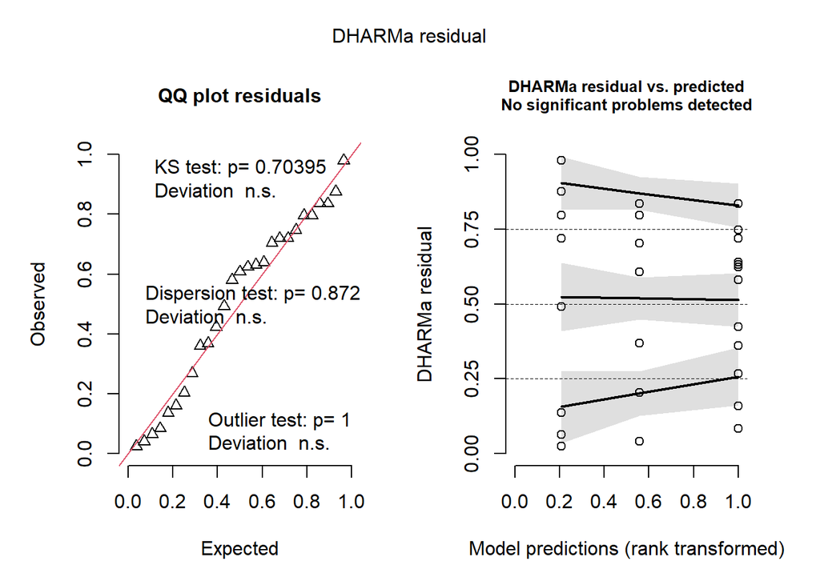

```r
# CTmax
simulationOutput <- simulateResiduals(O.SWmod1)

plot(simulationOutput)
```

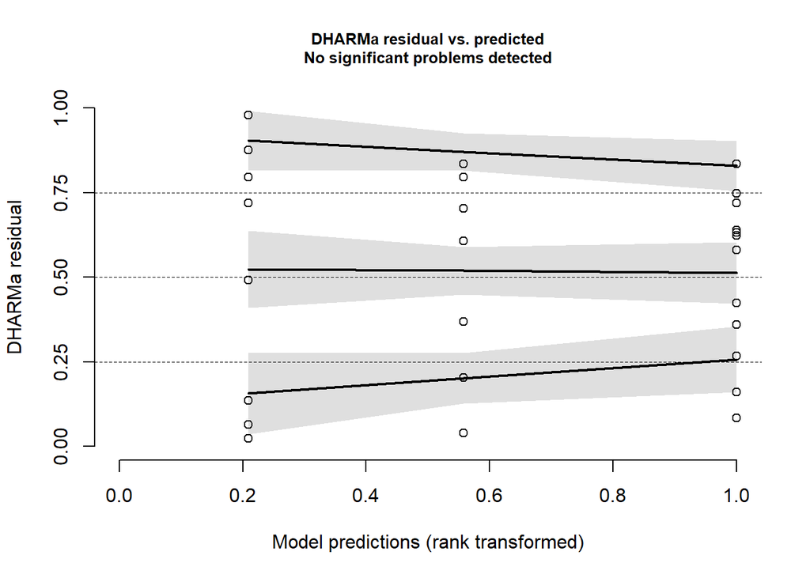

```r
plotResiduals(simulationOutput)
```

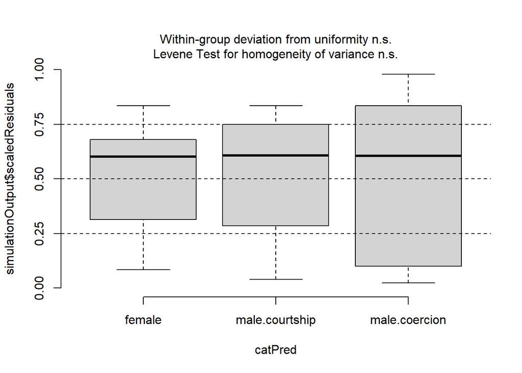

```r
plotResiduals(simulationOutput, form = O.swordtail_1$sex.2)
```

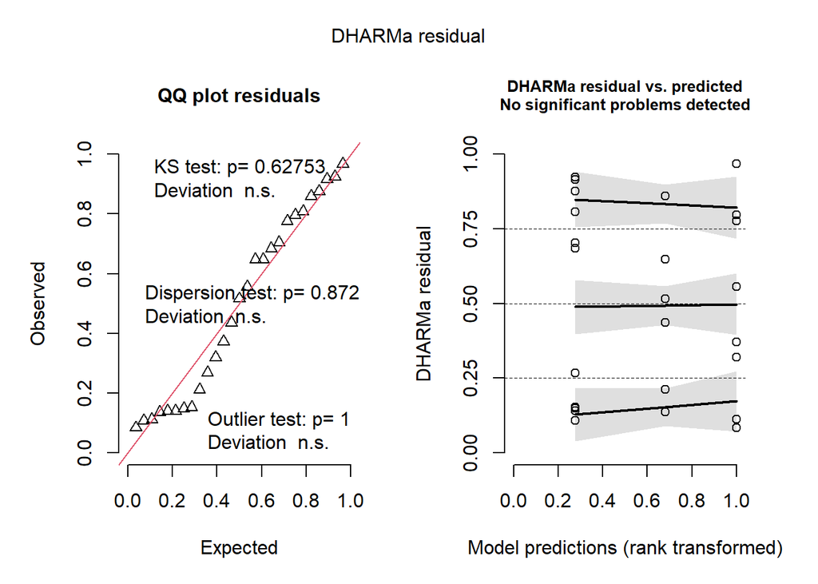

```r
  ### All good!

# CTmin
simulationOutput <- simulateResiduals(O.SWmod2)

plot(simulationOutput)
```

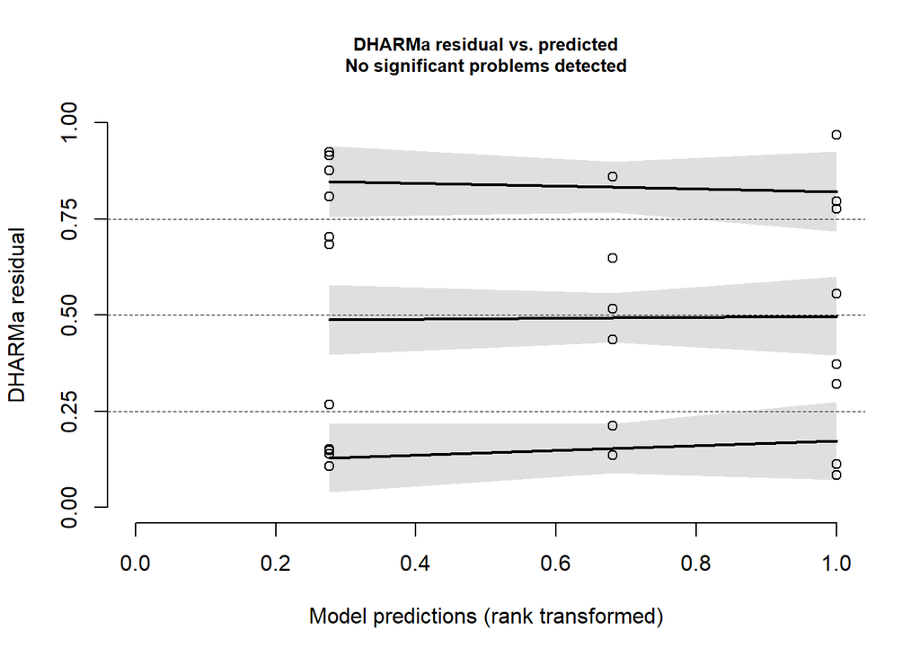

```r
plotResiduals(simulationOutput)
```

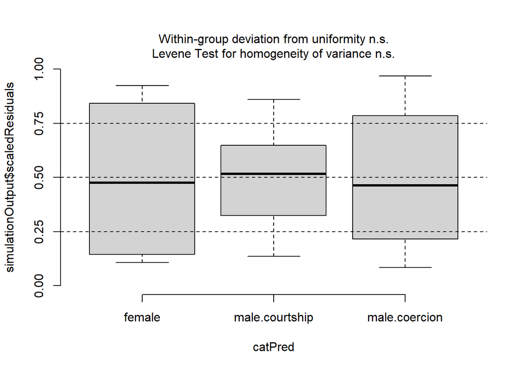

```r
plotResiduals(simulationOutput, form = O.swordtail_1$sex.2)
```

```r
  ### All good!
```

### Model Summary

**Results:** Mating strategy did not significantly affect thermal tolerance within swordtails across both temperature categories (CTmax: p=0.119; CTmin: p=0.343). This result is mirrored in all pairwise comparisons. For CTmax, the male-coercion coefficient was significant (p=0.04) but in conjunction with the other results, there is little support for any group differences. *These results mirror full-data results.*

```r
# CTmax

 ## Overall strategy effect
Anova(O.SWmod1, type="II")
```

```
## Anova Table (Type II tests)
##
## Response: CTmax.C
##           Sum Sq Df F value Pr(>F)
## sex.2     1.6547  2  2.3274 0.1192
## Residuals 8.5313 24
```

```r
 ## EMM & Pairwise comparisons

PW.sex.max <- emmeans(O.SWmod1, "sex.2")
summary(PW.sex.max) #EMM
```

```
##  sex.2          emmean    SE df lower.CL upper.CL
##  female           35.7 0.172 24     35.4     36.1
##  male.courtship   35.6 0.225 24     35.1     36.1
##  male.coercion    35.2 0.211 24     34.7     35.6
##
## Confidence level used: 0.95
```

```r
pairs(PW.sex.max) #Pairwise results
```

```
##  contrast                       estimate    SE df t.ratio p.value
##  female - male.courtship           0.155 0.284 24   0.547  0.8492
##  female - male.coercion            0.582 0.272 24   2.137  0.1034
##  male.courtship - male.coercion    0.427 0.309 24   1.382  0.3657
##
## P value adjustment: tukey method for comparing a family of 3 estimates
```

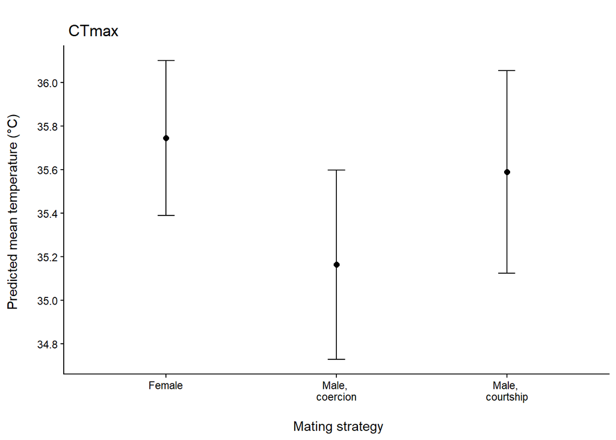

```r
  ## Plotting EMM

PW.df <- as.data.frame(PW.sex.max) %>%
  mutate(
    sex.2 = case_when(
      sex.2 == "female" ~ "Female",
      sex.2 == "male.courtship" ~ "Male, \ncourtship",
      sex.2 == "male.coercion" ~ "Male, \ncoercion"))


ggplot(PW.df, aes(x=sex.2, y=emmean)) +
  geom_point(size=2) +
  geom_errorbar(aes(ymin=lower.CL, ymax=upper.CL), width=0.1) +
  scale_y_continuous(breaks = scales::pretty_breaks(n = 10)) +
  ylab("Predicted mean temperature (°C) \n") +
  xlab("\n Mating strategy") +
  ggtitle("\n CTmax") +
  theme_classic()
```

```r
  ## Coefficients
summary(O.SWmod1)
```

```
##
## Call:
## lm(formula = CTmax.C ~ sex.2, data = O.swordtail_1)
##
## Residuals:
##     Min      1Q  Median      3Q     Max
## -1.1634 -0.4175  0.1600  0.3650  1.0866
##
## Coefficients:
##                     Estimate Std. Error t value Pr(>|t|)
## (Intercept)          35.7450     0.1721 207.684   <2e-16 ***
## sex.2male.courtship  -0.1550     0.2836  -0.547    0.590
## sex.2male.coercion   -0.5816     0.2721  -2.137    0.043 *
## ---
## Signif. codes:  0 '***' 0.001 '**' 0.01 '*' 0.05 '.' 0.1 ' ' 1
##
## Residual standard error: 0.5962 on 24 degrees of freedom
## Multiple R-squared:  0.1624, Adjusted R-squared:  0.09265
## F-statistic: 2.327 on 2 and 24 DF,  p-value: 0.1192
```

```r
# CTmin

## Overall strategy effect
Anova(O.SWmod2, type="II")
```

```
## Anova Table (Type II tests)
##
## Response: CTmin.C
##           Sum Sq Df F value Pr(>F)
## sex.2     0.7835  2    1.12 0.3427
## Residuals 8.3952 24
```

```r
 ## EMM & Pairwise comparisons

PW.sex.min <- emmeans(O.SWmod2, "sex.2")
summary(PW.sex.min) #EMM
```

```
##  sex.2          emmean    SE df lower.CL upper.CL
##  female           9.75 0.171 24     9.40     10.1
##  male.courtship   9.81 0.224 24     9.34     10.3
##  male.coercion   10.14 0.209 24     9.71     10.6
##
## Confidence level used: 0.95
```

```r
pairs(PW.sex.min) #Pairwise results
```

```
##  contrast                       estimate    SE df t.ratio p.value
##  female - male.courtship         -0.0545 0.281 24  -0.194  0.9796
##  female - male.coercion          -0.3900 0.270 24  -1.445  0.3348
##  male.courtship - male.coercion  -0.3355 0.306 24  -1.096  0.5256
##
## P value adjustment: tukey method for comparing a family of 3 estimates
```

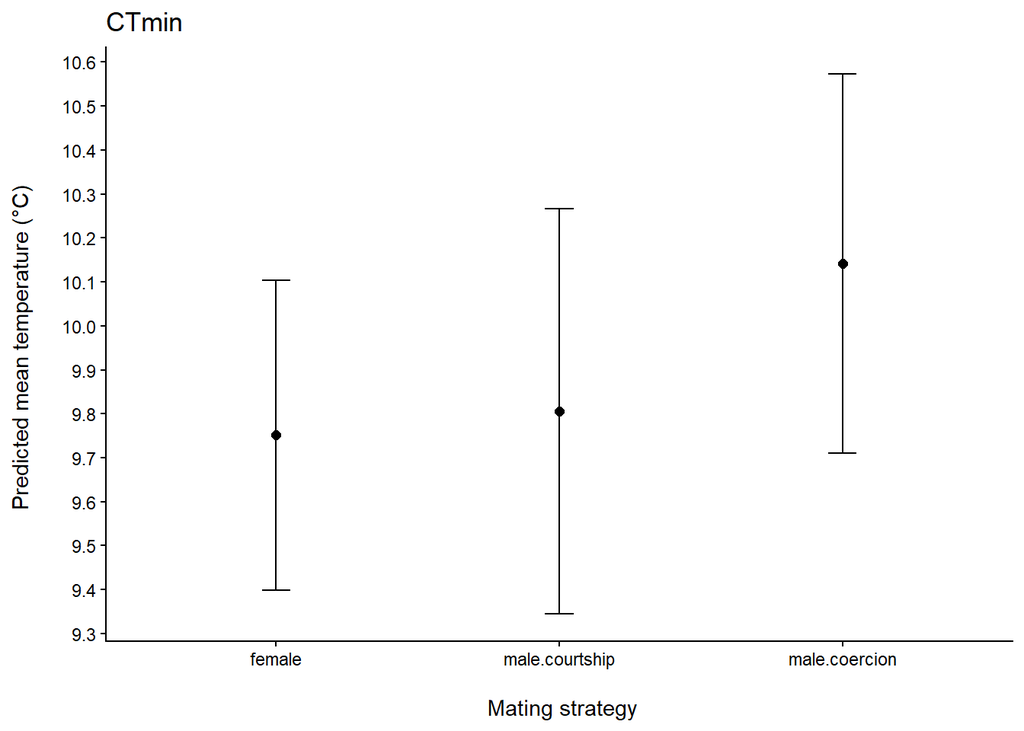

```r
  ## Plotting EMM

PW.df <- as.data.frame(PW.sex.min)

ggplot(PW.df, aes(x=sex.2, y=emmean)) +
  geom_point(size=2) +
  geom_errorbar(aes(ymin=lower.CL, ymax=upper.CL), width=0.1) +
  scale_y_continuous(breaks = scales::pretty_breaks(n = 10)) +
  ylab("Predicted mean temperature (°C) \n") +
  xlab("\n Mating strategy") +
  ggtitle("CTmin") +
  theme_classic()
```

```r
  ## Coefficients
summary(O.SWmod2)
```

```
##
## Call:
## lm(formula = CTmin.C ~ sex.2, data = O.swordtail_1)
##
## Residuals:
##      Min       1Q   Median       3Q      Max
## -0.83125 -0.61848  0.00429  0.49000  0.98375
##
## Coefficients:
##                     Estimate Std. Error t value Pr(>|t|)
## (Intercept)          9.75125    0.17073  57.114   <2e-16 ***
## sex.2male.courtship  0.05446    0.28128   0.194    0.848
## sex.2male.coercion   0.39000    0.26995   1.445    0.161
## ---
## Signif. codes:  0 '***' 0.001 '**' 0.01 '*' 0.05 '.' 0.1 ' ' 1
##
## Residual standard error: 0.5914 on 24 degrees of freedom
## Multiple R-squared:  0.08536,    Adjusted R-squared:  0.009145
## F-statistic:  1.12 on 2 and 24 DF,  p-value: 0.3427
```